# THU Big Data Preliminary

Hermit

2019-08-06

I participated in the 2019 Donghae University Big Data Competition. In this article, I will show waht kind of the problem we should do and how I finish the work.

※There is contest Description:

1.訓練數據(用於建立模型) 此數據為建模用，數據為熱壓爐成化加工過程所量測的溫度數據，總共有 8 個 群組的數據。群組內的每一個檔案為同一機台在一段連續時間內所量測數據， 8 個群組共有紀錄 230 個量測數據檔案，每一個檔案包含有五個到八個溫度數據欄位。

2.測驗數據(用於產生測驗結果): 測驗數據共有 36 組，皆由量測訓練數據機台所產生，數據格式與訓練數據相 同。測驗數據分類準確度為比賽結果依據。

3.比賽方式: 經由比賽團隊所訓練出來的模型，將測驗數據當作輸入數據，進行分類。主辦 方將各團隊的 36 組測驗數據分類結果經過分類準確度計算，進行團隊排名， 做為入圍決賽之依據。

資料型態為8個資料夾，分別代表8個不同分類，資料夾內有數個機台溫度的txt檔案，其呈現方式為垂直觀測資料，故我們先以R讀入大量txt資料，再將垂直格式轉為水平格式，並且幫各比溫度資料標記其所屬的分類，以1~8的factor為代稱，以方便我們做後續分析。

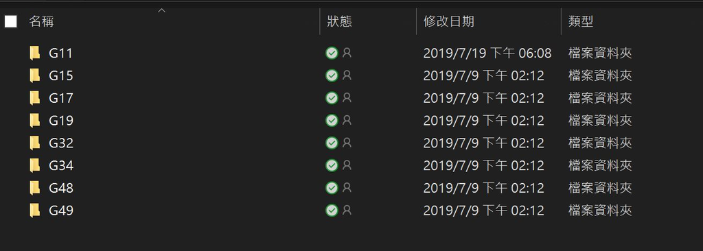

※訓練資料圖示1

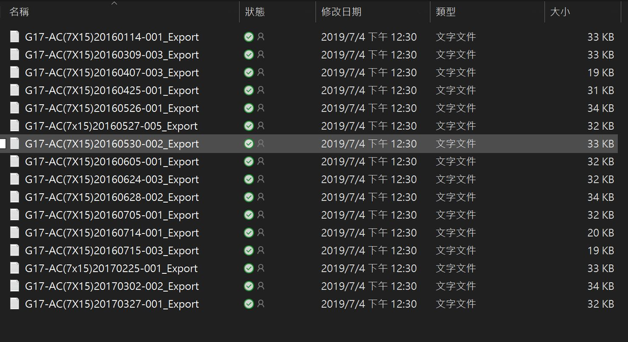

※訓練資料圖示2

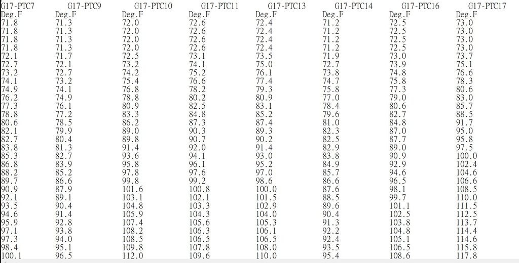

thu3

※訓練資料圖示3

# Read data

說明:以下程式在資料目錄及其底下的txt檔架構不變下，只需要更改資料夾位置即可  
例如:假設訓練資料「大數據競賽初賽資料(230測試數據)」位於D槽目錄下，  
將path改成 path <- “D:/大數據競賽初賽資料(230測試數據)/”即可

```r
path <- "C:\\Users\\User\\OneDrive\\Lin\\NSYSU\\thu_bigdata\\thubigdata2019training-230\\"
```

同理，更改測試資料夾位置即可 例如:假設測試資料夾「thubigdata2019exam-722」位於C槽的user， 將pathtest改成“C:/user/thubigdata2019exam-722/”即可

```r
pathtest <- "C:\\Users\\User\\OneDrive\\Lin\\NSYSU\\thu_bigdata\\test_model\\"
```

# Part2:Install packages

準備幾個會使用到的package

```r
necessary = c("readr","dplyr","plyr","randomForest")
installed = necessary %in% installed.packages()[, 'Package']
if (length(necessary[!installed]) >=1)
  install.packages(necessary[!installed])
library(readr)
library(plyr)
library(randomForest)
```

# Part3:Data processing

## Train data

```r
txt= function(txt){
  read_delim(txt,delim = "\t",col_names = TRUE)[-1,]
}


site = c("G11","G15","G17","G19","G32","G34","G48","G49")

for(i in 1:length(site)){
  g11data = lapply(paste0(path = paste0(path,site[i],"/"),list.files(path = paste0(path,site[i],"/"), pattern = "*.txt"),sep=""),txt)
  #G11
  if(site[i]=="G11"){
    for(k in 1:length(g11data)){
      g11data[[k]] = apply(g11data[[k]],2,as.numeric)
      for(j in 1 : length(colnames(g11data[[i]]))){
        num = nchar(colnames(g11data[[i]])[j])
        colnames(g11data[[i]])[j] = substr(colnames(g11data[[i]])[j],5,num-2)
      }
    }
    data = rbind.fill(as.data.frame(t(g11data[[1]][,-dim(g11data[[1]])[2]])))
    for(l in c (2:23)){
      data <- rbind.fill(data,as.data.frame(t(g11data[[l]][,-dim(g11data[[l]])[2]])))
    }
    data[is.na(data)] <- 0
  }
  #G15
  else if(site[i]=="G15"){
    g15data = lapply(paste0(path = paste0(path,site[i],"/"),list.files(path = paste0(path,site[i],"/"), pattern = "*.txt"),sep=""),txt)
    for(k in 1:length(g15data)){
      g15data[[k]] = apply(g15data[[k]],2,as.numeric)
      for(j in 1 : length(colnames(g15data[[i]]))){
        num = nchar(colnames(g15data[[i]])[j])
        colnames(g15data[[i]])[j] = substr(colnames(g15data[[i]])[j],5,num-2)
      }
    }
    for(l in c (1:31)){
      data <- rbind.fill(data,as.data.frame(t(g15data[[l]][,-dim(g15data[[l]])[2]])))
    }
    data[is.na(data)] <- 0
  }
  #G17
  else if(site[i]=="G17"){
    g17data = lapply(paste0(path = paste0(path,site[i],"/"),list.files(path = paste0(path,site[i],"/"), pattern = "*.txt"),sep=""),txt)
    for(k in 1:length(g17data)){
      g17data[[k]] = apply(g17data[[k]],2,as.numeric)
      for(j in 1 : length(colnames(g17data[[i]]))){
        num = nchar(colnames(g17data[[i]])[j])
        colnames(g17data[[i]])[j] = substr(colnames(g17data[[i]])[j],5,num-2)
      }
    }
    for(l in c (1:16)){
      data <- rbind.fill(data,as.data.frame(t(g17data[[l]][,-dim(g17data[[l]])[2]])))
    }
    data[is.na(data)] <- 0
  }
  #G19
  else if(site[i] == "G19"){
    g19data = lapply(paste0(path = paste0(path,site[i],"/"),list.files(path = paste0(path,site[i],"/"), pattern = "*.txt"),sep=""),txt)
    for(k in 1:length(g19data)){
      g19data[[k]] = apply(g19data[[k]],2,as.numeric)
      for(j in 1 : length(colnames(g19data[[i]]))){
        num = nchar(colnames(g19data[[i]])[j])
        colnames(g19data[[i]])[j] = substr(colnames(g19data[[i]])[j],5,num-2)
      }
    }
    for(l in c (1:30)){
      data <- rbind.fill(data,as.data.frame(t(g19data[[l]][,-dim(g19data[[l]])[2]])))
    }
    data[is.na(data)] <- 0
  }
  #G32
  else if(site[i] == "G32"){
    g32data = lapply(paste0(path = paste0(path,site[i],"/"),list.files(path = paste0(path,site[i],"/"), pattern = "*.txt"),sep=""),txt)
    for(k in 1:length(g32data)){
      g32data[[k]] = apply(g32data[[k]],2,as.numeric)
      for(j in 1 : length(colnames(g32data[[i]]))){
        num = nchar(colnames(g32data[[i]])[j])
        colnames(g32data[[i]])[j] = substr(colnames(g32data[[i]])[j],5,num-2)
      }
    }
    for(l in c (1:32)){
      data <- rbind.fill(data,as.data.frame(t(g32data[[l]][,-dim(g32data[[l]])[2]])))
    }
    data[is.na(data)] <- 0
  }
  #G34
  else if(site[i] == "G34"){
    g34data = lapply(paste0(path = paste0(path,site[i],"/"),list.files(path = paste0(path,site[i],"/"), pattern = "*.txt"),sep=""),txt)
    for(k in 1:length(g34data)){
      g34data[[k]] = apply(g34data[[k]],2,as.numeric)
      for(j in 1 : length(colnames(g34data[[i]]))){
        num = nchar(colnames(g34data[[i]])[j])
        colnames(g34data[[i]])[j] = substr(colnames(g34data[[i]])[j],5,num-2)
      }
    }
    for(l in c (1:33)){
      data <- rbind.fill(data,as.data.frame(t(g34data[[l]][,-dim(g34data[[l]])[2]])))
    }
    data[is.na(data)] <- 0
  }
  #G48
  else if(site[i]=="G48"){
    g48data = lapply(paste0(path = paste0(path,site[i],"/"),list.files(path = paste0(path,site[i],"/"), pattern = "*.txt"),sep=""),txt)
    for(k in 1:length(g48data)){
      g48data[[k]] = apply(g48data[[k]],2,as.numeric)
      for(j in 1 : length(colnames(g48data[[i]]))){
        num = nchar(colnames(g48data[[i]])[j])
        colnames(g48data[[i]])[j] = substr(colnames(g48data[[i]])[j],5,num-2)
      }
    }
    for(l in c (1:31)){
      data <- rbind.fill(data,as.data.frame(t(g48data[[l]][,-dim(g48data[[l]])[2]])))
    }
    data[is.na(data)] <- 0
  }
  #G49
  else{
    g49data = lapply(paste0(path = paste0(path,site[i],"/"),list.files(path = paste0(path,site[i],"/"), pattern = "*.txt"),sep=""),txt)
    for(k in 1:length(g49data)){
      g49data[[k]] = apply(g49data[[k]],2,as.numeric)
      for(j in 1 : length(colnames(g49data[[i]]))){
        num = nchar(colnames(g49data[[i]])[j])
        colnames(g49data[[i]])[j] = substr(colnames(g49data[[i]])[j],5,num-2)
      }
    }
    for(l in c (1:34)){
      data <- rbind.fill(data,as.data.frame(t(g49data[[l]][,-dim(g49data[[l]])[2]])))
    }
    data[is.na(data)] <- 0
  }
}

a = rep(1,145)
b = rep(2,207)
c = rep(3,119)
d = rep(4,238)
e = rep(5,256)
f = rep(6,264)
g = rep(7,244)
h = rep(8,272)
data$y = c(a,b,c,d,e,f,g,h)
```

## Test data

測試資料與訓練資料呈現類似，以36個txt檔案呈現，並期望我們能預測36筆資料分別為哪些類別。

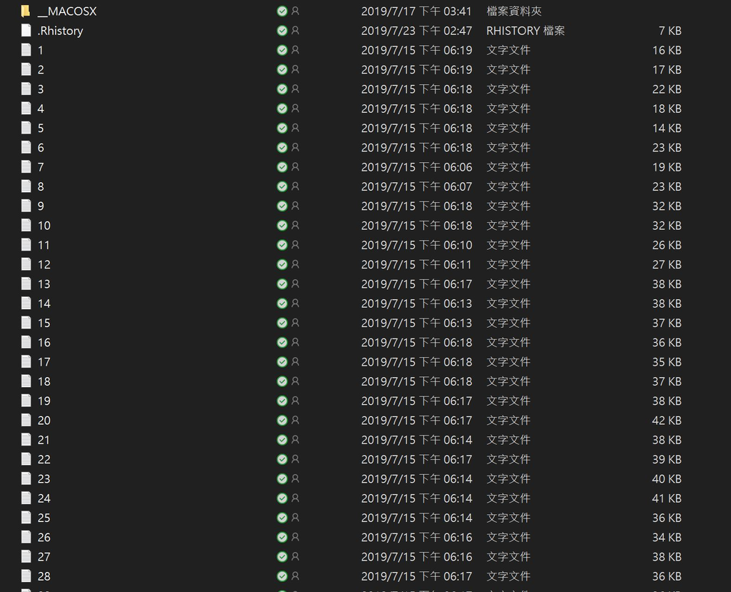

※測試資料圖示1

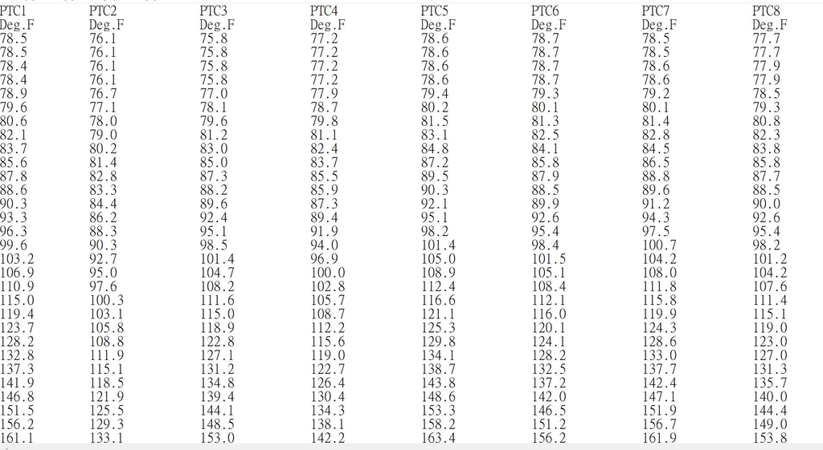

※測試資料圖示2

```r
g49 <- list.files(path = pathtest, pattern = "*.txt")
g49data = lapply(paste0(path = pathtest,g49,sep=""),txt)
for(i in 1:length(g49data)){
  g49data[[i]] = apply(g49data[[i]],2,as.numeric)
  for(j in 1 : length(colnames(g49data[[i]]))){
    num = nchar(colnames(g49data[[i]])[j])
    colnames(g49data[[i]])[j] = substr(colnames(g49data[[i]])[j],5,num-2)
  }
}
data1 = rbind.fill(as.data.frame(t(g49data[[1]])))
for(i in c (2:36)){
  data1 <- rbind.fill(data1,as.data.frame(t(g49data[[i]])))
}
data1[is.na(data1)] <- 0
data1 <- data1[-which(data1$V1== 0),]

test = c(rep(1,5),rep(10,8),rep(11,8),rep(12,8),rep(13,8),rep(14,8),rep(15,8),rep(16,8),rep(17,8),rep(18,8),rep(19,8),rep(2,5),rep(20,8),rep(21,8),rep(22,8),rep(23,8),rep(24,8),rep(25,8),rep(26,8),rep(27,8),rep(28,8),rep(29,8),rep(3,8),rep(30,8),rep(31,8),rep(32,8),rep(33,8),rep(34,8),rep(35,8),rep(36,8),rep(4,6),rep(5,6),rep(6,8),rep(7,6),rep(8,8),rep(9,8))

data1$test <- test
test = data1
```

# Part4:Data analyzing

## Data Visualization

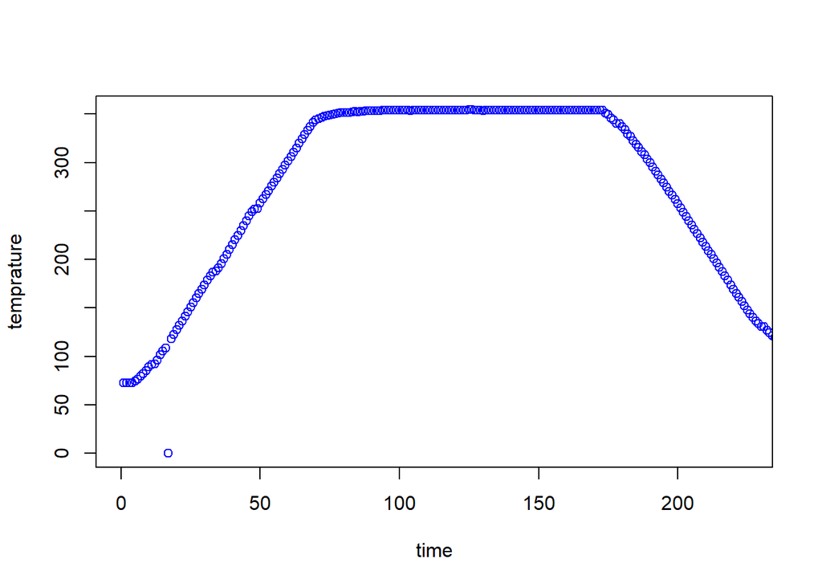

```r
temprature = as.numeric(data1[1,])
plot(temprature,xlab = "time", xlim = c(0,225),col="blue")
```

我們已知機台為持續加溫，因此其溫度變化的特徵是一個可作為類別區分的依據，因此我們在最一開始分析時，使用各串溫度資料的某些特徵進行分析，例如最大溫度、穩態溫度時間長度、溫度下降點等。但在訓練過程中，我們嘗試了多種分類方法，如常見的SVM、XGB、隨機森林等，但因各PTC差異甚小，且保留過少的溫度特徵，因此效果並不理想。後續使用集成學習(stacking)的方法，但交叉驗證的預測準確率也僅約70%左右。

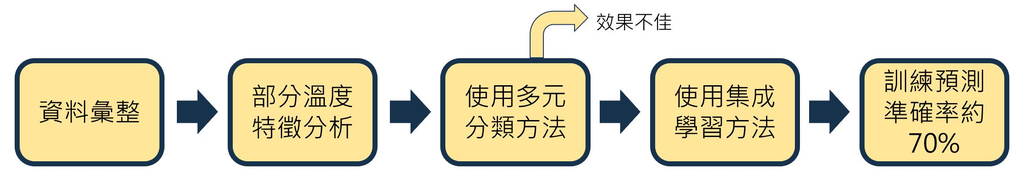

※分析流程1

後來透過分析方法推得相異PTC並無顯著影響分類結果，因此使用不考慮PTC差異的全溫度資料進行分類，在使用各類多元分類方法以及集成方法後，訓練資料的交叉驗證準確率皆高達99%，因此在最後我們決定使用不易過度擬合的分類方法：隨機森林，來當作我們這次的最終分類模型。

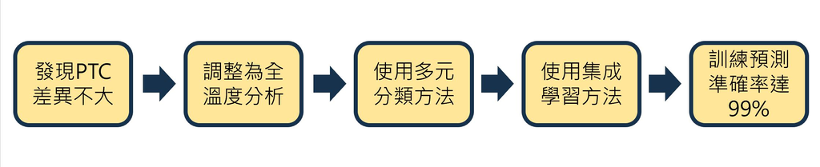

※分析流程2

## RandomForest

以下是我們對最終36機台的分類預測，模型為RandomForest

```r
zero = matrix(rep(0,42*276),ncol = 42)
test = cbind(test,zero)
colnames(test) = c(paste0("V",1:449))

data$y = as.factor(data$y)
machine = data$y
label = as.integer(data$y)-1
data$y = NULL

model = randomForest(as.factor(label)~.,data= data,boos = TRUE)
predran = predict(model,test)
predran = as.numeric(data.frame(predran)[,1])

for(i in 1:length(g49data)){
  g49data[[i]] = apply(g49data[[i]],2,as.numeric)
  for(j in 1 : length(colnames(g49data[[i]]))){
    colnames(g49data[[i]])[j] = paste0("PTC",j)
  }
  if(table(is.na(g49data[[i]]))[[1]] != ncol(g49data[[i]])*nrow(g49data[[i]])){
    g49data[[i]] = g49data[[i]][,-ncol(g49data[[i]])]
  }
}
len = c()
len = vector()
for(i in 1:36){
  len[i] = length(colnames(g49data[[i]]))
}

predran[which(predran == "1")] = "G11"
predran[which(predran == "2")] = "G15"
predran[which(predran == "3")] = "G17"
predran[which(predran == "4")] = "G19"
predran[which(predran == "5")] = "G32"
predran[which(predran == "6")] = "G34"
predran[which(predran == "7")] = "G48"
predran[which(predran == "8")] = "G49"

j = 0
l = 1
k = c(1,10:19,2,20:29,3,30:36,4:9)
for(i in len){
  j = i+j
  print(paste0("第",k[l],"筆測試資料是屬於",predran[j],"機台"))
  l = l+1
}
```

```
## [1] "第1筆測試資料是屬於G11機台"
## [1] "第10筆測試資料是屬於G17機台"
## [1] "第11筆測試資料是屬於G19機台"
## [1] "第12筆測試資料是屬於G19機台"
## [1] "第13筆測試資料是屬於G32機台"
## [1] "第14筆測試資料是屬於G32機台"
## [1] "第15筆測試資料是屬於G32機台"
## [1] "第16筆測試資料是屬於G32機台"
## [1] "第17筆測試資料是屬於G32機台"
## [1] "第18筆測試資料是屬於G32機台"
## [1] "第19筆測試資料是屬於G34機台"
## [1] "第2筆測試資料是屬於G11機台"
## [1] "第20筆測試資料是屬於G34機台"
## [1] "第21筆測試資料是屬於G34機台"
## [1] "第22筆測試資料是屬於G34機台"
```

[output cut: 21 more lines]